# Seqtometry vignette

10 January 2026

# 1 Basic workflow

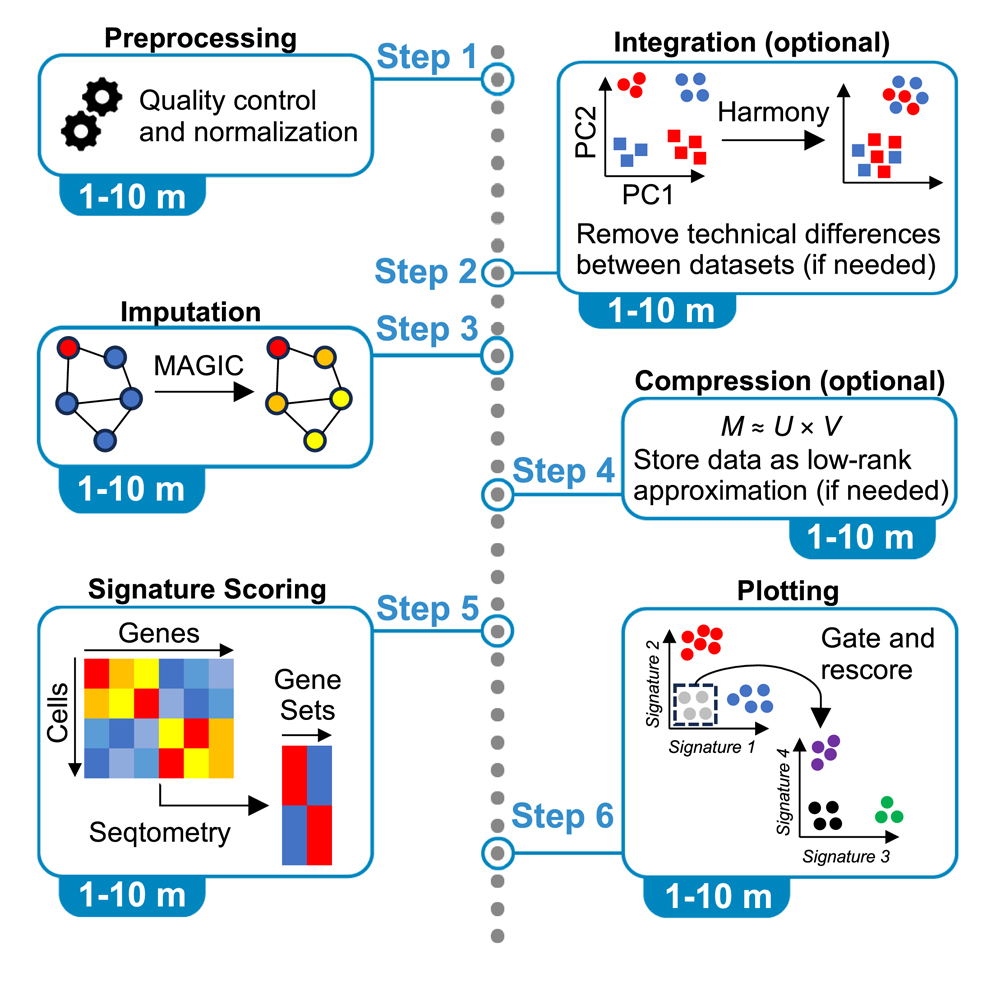

This vignette contains a simple example of a Seqtometry workflow involving peripheral blood mononuclear cell (PBMC) data. Herein, 4 immune cell populations will be identified using corresponding signatures (gene sets). For more advanced workflows, please see the [STAR Protocols publication](https://doi.org/10.1016/j.xpro.2024.103209).

## 1.1 Retrieve data and signatures

Load a small PBMC dataset and associated signatures.

```r
# Gene expression data (with gene symbols)
dat <- TENxPBMCData::TENxPBMCData(dataset = "pbmc3k")
gex <- SingleCellExperiment::counts(dat) |> as("dgCMatrix")
dimnames(gex) <- list(
  SingleCellExperiment::rowData(dat)[["Symbol_TENx"]],
  dat[["Barcode"]])

# Signatures (consisting of gene symbols)
sig_names <- c("T cell", "B cell", "NK cell", "Monocyte")
sig_url <- "https://ars.els-cdn.com/content/image/1-s2.0-S2405471223003599-mmc2.xlsx"
sig <- openxlsx::read.xlsx(sig_url) |>
  dplyr::filter(Signature.name %in% sig_names) |>
  dplyr::mutate(Genes = stringr::str_split(Genes, ", ")) |>
  dplyr::pull(Genes, name = Signature.name)
```

## 1.2 Preprocessing and imputation

Perform quality control, normalization, and MAGIC imputation (van Dijk et al. 2018).

```r
qc <- function(mat) {
  # Indices of mitochondrial genes
  mito_idx <- grep("^MT-", rownames(mat))

  # Calculate QC metrics
  res <- mat |>
    scuttle::perCellQCMetrics(subsets = list("Mito" = mito_idx)) |>
    scuttle::perCellQCFilters(sub.fields = "subsets_Mito_percent")

  # Remove low quality cells
  mat[, !res$discard]
}

imputed_gex <- gex |>
  qc() |>
  scuttle::normalizeCounts() |>
  Seqtometry::impute()
```

## 1.3 Score and plot data

Score the data for the *T cell* and *B cell* signatures.

```r
# May set up parallel backend if it is supported
# Will default to non-parallel (sequential) execution
future::plan("sequential")

# Allot 1 GiB of memory for global variables
options(future.globals.maxSize = 1024 ^ 3)

# Scoring with lymphocyte signatures
scores <- sig[c("T cell", "B cell")] |>
  Seqtometry::score(imputed_gex, signatures = _)
```

Create a plot from the signature scores.

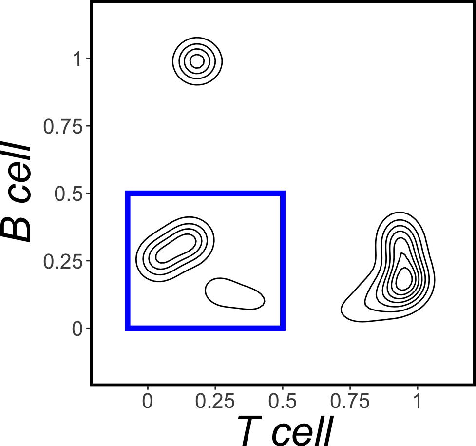

```r
# Avoid having to prefix common plot elements with ggplot2::
library(ggplot2)

# A flow cytometry style theme for plots
theme_custom <- theme_bw() + theme(
  aspect.ratio = 1,
  panel.grid = element_blank(),
  panel.background = element_blank(),
  panel.border = element_rect(color = "black", fill = NA, linewidth = 2),
  axis.title = element_text(size = 32, face = "italic"),
  axis.text = element_text(size = 16))

# Utility function for generating flow cytometry style plots
biaxial_plot <- function(d, x, y) {
  lim <- c(-0.15, 1.15)
  brk <- seq(0, 1, 0.25)
  lbl <- c("0", "0.25", "0.5", "0.75", "1")
  ggplot(d, aes(x = .data[[x]], y = .data[[y]])) +
    geom_density_2d(color = "black", h = c(0.2, 0.2),
      contour_var = "ndensity", binwidth = 0.125) +
    scale_x_continuous(limits = lim, breaks = brk, labels = lbl) +
    scale_y_continuous(limits = lim, breaks = brk, labels = lbl) +
    theme_custom
}

# Utility function to draw a rectangular region
rect_region <- function(lims) {
  do.call(annotate, c(lims, geom = "rect",
    color = "blue", fill = NA, linewidth = 2))
}

# Limits defining a rectangular region for double negative cells
dn_lims <- list(xmin = -0.075, xmax = 0.5, ymin = 0, ymax = 0.5)

# Draw the biaxial plot with the rectangular region
biaxial_plot(scores, "T cell", "B cell") + rect_region(dn_lims)
```

Extract (gate) the cells negative for both signatures. Then, rescore the gated cells with the *Monocyte* and *NK cell* signatures and visualize the results.

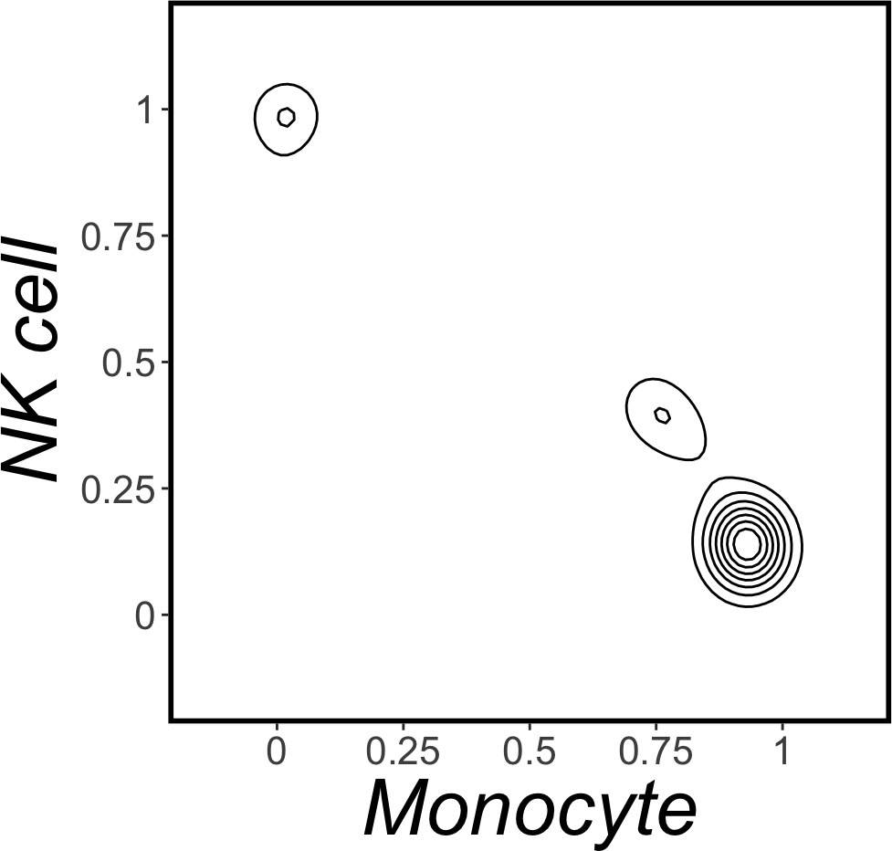

```r
# Subset the imputed data, keeping only the cells in the blue region
gated_imputed_gex <- with(scores,
  imputed_gex[, `T cell` < dn_lims$xmax & `B cell` < dn_lims$ymax])

# Score the subsetted data with the remaining signatures
gated_scores <- sig[c("NK cell", "Monocyte")] |>
  Seqtometry::score(gated_imputed_gex, signatures = _)

# Plot the new scores
biaxial_plot(gated_scores, "Monocyte", "NK cell")
```

The above steps demonstrate how plots constructed from signature scores (using the Seqtometry scoring algorithm) can be used to identify major PBMC populations in a hierarchical fashion (in a manner akin to flow cytometry).

Additional characterization of cells can be accomplished by employing signatures corresponding to biological processes of interest. Please see the [Seqtometry publication (Cell Systems)](https://doi.org/10.1016/j.cels.2023.12.005) for examples.